# Module 5: Model Diagnostics and Seasonality

### 5.9.5 Adjustment as the Logical Conjugate

Section 5.8.4 said adjustment is a model, and that the field’s tests and the field’s adjustment filters answer different questions — the test asks about one population object, the filter removes another, and the two do not speak the same language. The design principle of the working paper is to close that gap: **the adjustment should remove exactly the excess the test detects,** so that re-running the test on the adjusted series fails to reject *by construction*. Test and adjustment share a partition and a target. They are logical conjugates.

The operator that delivers it is **stochastic spectral imputation (SSI)**, in three moves:

1. **Setup.** Take the DFT of the whitened series. The ordinates in the seasonal bins are the **targets**; the quiet ordinates below a chosen quantile of the non-seasonal floor are the **donors**.
2. **Impute.** For each target, draw a donor at random and reset the target’s *magnitude* to the donor’s level, keeping the target’s own phase. This is the stochastic step — the seasonal bins are filled with draws from the non-seasonal floor rather than set to zero, so the adjusted series keeps a realistic noise level at those frequencies instead of a spectral hole.
3. **Finalize.** Enforce conjugate symmetry, invert the DFT, recolour through the whitener, and restore the levels.

The call below is the **classic SSI** path — every seasonal-bin ordinate imputed, each keeping its own phase as in step 2 (`phase_rule = "zero"` is the package’s name for this classic rule, not an instruction to zero phases) — with a fixed seed so the draw is reproducible:

```r
adj_ssi <- seas_adjust(unratensa, phase_rule = "zero", target_set = "bins", seed = 6376)
adj_ssi
```

```
SSI seasonal adjustment (classic)
 detection p = 0 | spec: band (shoulder p = 0.00606, phase R = 0.99)
 phase rule: zero  [declared identification]
 imputation: bootstrap, B = 1, targets = bins (113), seed = 6376
 M = 19 (suggest_M, offset-free) | whitener: d = 1, AR(2) on M0 ordinates | seasonal alignment trimmed 9 leading residuals (first 12 obs. unadjusted)
 post-adjustment detection p = 0.877
```

```r
ssi_nsa  <- adjusted(adj_ssi)     # the adjusted series (first 12 months left as raw, see below)
test_ssi <- seas_test(ssi_nsa)    # re-run the same test on the output
test_ssi
```

```
freqseas seasonality test
 decision: not seasonal (detection p = 0.877, alpha = 0.05)
 spec: line (shoulder p = 0.872, phase R = 0.26)
 M = 19 (suggest_M, offset-free) | whitener: d = 1, AR(2) on M0 ordinates | seasonal alignment trimmed 9 leading residuals (first 12 obs. unadjusted)
```

```r
unlist(test_ssi$evt)              # statistic, p-value, critical value, N1, N0
```

```
  statistic           p    critical          N1          N0
 -2.7166387   0.8768991   2.1911879 113.0000000 240.0000000
```

The post-adjustment test fails to reject — $\hat\Delta \approx -2.7$, $p \approx 0.88$ — which is the conjugate property doing what it promises. (The adjustment leaves the first twelve months unadjusted: with one difference and an AR(2) whitener, the seasonal alignment of the imputed series starts after the whitener’s burn-in, and the package says so in its printout.)

One honest sentence about the package, because you will be tempted to call it with no options: `seas_adjust()`’s *default* branch is a different, experimental object — on a series the test classifies as a “band” (a broad seasonal hump rather than a line), the default divides by an estimated gain and imputes nothing, and on `UNRATENSA` its own post-test rejects. The “by construction” claim attaches to the classic call above, which is the path the working paper describes. Verify it yourself:

```r
adj_default <- seas_adjust(unratensa, seed = 6376)   # package defaults: the band branch
signif(c(post_p_default = glance(adj_default)$post_p,
         post_p_classic = glance(adj_ssi)$post_p), 3)
```

```
post_p_default post_p_classic
      2.71e-10       8.77e-01
```

Lay the SSI output against the published series and the raw series:

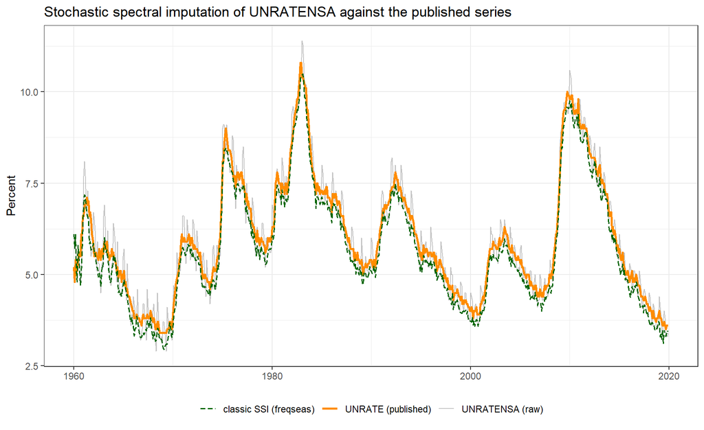

```r
cmp$ssi <- as.numeric(ssi_nsa)

ggplot(cmp, aes(date)) +
  geom_line(aes(y = raw, colour = "UNRATENSA (raw)"), linewidth = 0.4, alpha = 0.5) +
  geom_line(aes(y = published, colour = "UNRATE (published)"), linewidth = 1) +
  geom_line(aes(y = ssi, colour = "classic SSI (freqseas)"), linewidth = 0.7, linetype = "42") +
  scale_colour_manual(values = c("UNRATENSA (raw)" = "grey55",
                                 "UNRATE (published)" = "darkorange",
                                 "classic SSI (freqseas)" = "darkgreen"), name = NULL) +
  ggtitle("Stochastic spectral imputation of UNRATENSA against the published series") +
  ylab("Percent") + xlab(NULL) + theme_bw() + theme(legend.position = "bottom")
```

```r
keep <- seq_along(cmp$date) > 12   # exclude the unadjusted head
round(c(corr_with_published = cor(cmp$ssi[keep], cmp$published[keep]),
        mean_abs_diff       = mean(abs(cmp$ssi[keep] - cmp$published[keep]))), 3)
```

```
corr_with_published       mean_abs_diff
              0.997               0.298
```

SSI tracks the published series but is rougher than X-13’s default output — a mean absolute gap of about 0.3 percentage points against X-13’s 0.065. That is by design: SSI removes seasonal *excess* down to the noise floor and stops; it does not try to replicate a production adjustment, and it does not smooth. The working paper argues that this is a feature — X-13 tends to remove more variance than the seasonal component contains and to dig a dip at the seasonal frequencies — but that argument is beyond these notes.

### 5.9.6 The Bridge Back to the Epilogue

Finally, the question Section 5.8.4 could not answer without a definition: **does the published `UNRATE` still carry seasonality?** Run the same test on it, and on the X-13 output from Section 5.8.4 for comparison:

```r
test_pub <- seas_test(unrate)
test_pub
```

```
freqseas seasonality test
 decision: not seasonal (detection p = 0.233, alpha = 0.05)
 spec: line (shoulder p = 0.225, phase R = 0.42)
 M = 19 (suggest_M, offset-free) | whitener: d = 1, AR(3) on M0 ordinates | seasonal alignment trimmed 8 leading residuals (first 12 obs. unadjusted)
```

```r
unlist(test_pub$evt)              # statistic, p-value, critical value, N1, N0
```

```
  statistic           p    critical          N1          N0
  0.4361415   0.2333676   2.1911879 113.0000000 240.0000000
```

```r
tidy(test_pub)                    # per-harmonic excess
```

```
# A tibble: 6 × 4
  omega label  excess elevated
  <dbl> <chr>   <dbl> <lgl>
1 0.524 pi/6    -4.61 FALSE
2 1.05  pi/3    -3.85 FALSE
3 1.57  pi/2    -4.45 FALSE
4 2.09  2*pi/3  -4.58 FALSE
5 2.62  5*pi/6  -4.28 FALSE
6 3.14  pi      -4.42 FALSE
```

```r
test_x13 <- seas_test(sa_x13)
test_x13
```

```
freqseas seasonality test
 decision: not seasonal (detection p = 0.651, alpha = 0.05)
 spec: line (shoulder p = 0.641, phase R = 0.27)
 M = 19 (suggest_M, offset-free) | whitener: d = 1, AR(3) on M0 ordinates | seasonal alignment trimmed 8 leading residuals (first 12 obs. unadjusted)
```

```r
unlist(test_x13$evt)
```

```
  statistic           p    critical          N1          N0
 -1.3779603   0.6512888   2.1911879 113.0000000 240.0000000
```

Both fail to reject: $\hat\Delta \approx 0.44$ with $p \approx 0.23$ on the published series, $\hat\Delta \approx -1.4$ with $p \approx 0.65$ on the default X-13 output. Under this definition, neither adjusted series has seasonal *excess*. And the per-harmonic table for the published series already hints at the epilogue’s reading: every harmonic’s measured excess is **negative** — the seasonal-bin ordinates sit *below* the donor level.

**Is it a dip?** A peak-dominance test is one-sided: it was built to detect excess, and it correctly reports none. To ask the opposite question — whether the seasonal frequencies carry *less* power than the bands beside them — we can measure the shape directly on the same object the test looked at. Take the test’s fixed partition, and for each seasonal bin divide the mean standardized periodogram ordinate of the whitened residuals by the mean over the bin’s two neighbouring non-seasonal bins. A ratio below one is a dip; above one is an excess. The canonical copy of this helper lives in `helpers/seasonality.R`:

```r
seasonal_bin_ratios <- function(test) {
  # Seasonal-bin dip check on a freqseas seas_test() object: for each seasonal
  # bin of the test's fixed partition, the mean standardized periodogram
  # ordinate of the whitened residuals divided by the mean over the bin's
  # neighbouring non-seasonal bins. Below 1 = dip, above 1 = excess. The
  # Nyquist ordinate is excluded, as in the package's detection statistic.
  breaks <- test$partition$breaks
  M1     <- test$partition$M1
  n_bins <- length(breaks) - 1L
  n      <- test$pgram$n
  j      <- seq_len(floor(n / 2))
  omega  <- 2 * pi * j / n                 # Fourier frequencies, radians per obs
  I      <- test$pgram$pgram_std[j + 1L]   # element i is Fourier index j = i - 1
  keep   <- omega > 0 & abs(omega - pi) > 1e-9
  omega  <- omega[keep]; I <- I[keep]
  bin    <- findInterval(omega, breaks, left.open = TRUE, rightmost.closed = TRUE)

  neighbours <- function(m) setdiff(intersect(c(m - 1L, m + 1L), seq_len(n_bins)), M1)
  labels <- if (length(M1) == 6) c("pi/6", "pi/3", "pi/2", "2pi/3", "5pi/6", "pi") else paste0("bin ", M1)
  harm   <- if (length(M1) == 6) (1:6) * pi / 6 else rep(NA_real_, length(M1))

  rows <- lapply(seq_along(M1), function(k) {
    m <- M1[k]; nb <- neighbours(m); nb_mean <- mean(I[bin %in% nb])
    # the single ordinate sitting on the harmonic itself (NA if none is on the
    # Fourier grid, as at the Nyquist frequency, whose ordinate is excluded)
    ih <- which.min(abs(omega - harm[k]))
    on_grid <- !is.na(harm[k]) && abs(omega[ih] - harm[k]) <= 0.51 * pi / length(omega)
    data.frame(harmonic = labels[k], bin = m,
               bin_mean = mean(I[bin == m]), neighbour_mean = nb_mean,
               ratio = mean(I[bin == m]) / nb_mean,
               harmonic_ratio = if (on_grid) I[ih] / nb_mean else NA_real_)
  })
  out <- do.call(rbind, rows)
  nb_all <- unique(unlist(lapply(M1, neighbours)))
  attr(out, "overall") <- mean(I[bin %in% M1]) / mean(I[bin %in% nb_all])
  out
}
```

```r
tests3 <- list("UNRATENSA (raw)" = test_nsa,
               "UNRATE (published)" = test_pub,
               "X-13 default output" = test_x13)
dips <- lapply(tests3, seasonal_bin_ratios)

dip_table <- do.call(rbind, lapply(names(dips), function(nm) {
  r <- dips[[nm]]
  data.frame(series = nm, t(setNames(round(r$ratio, 2), r$harmonic)),
             overall = round(attr(r, "overall"), 2),
             bins_below_1 = sum(r$ratio < 1), check.names = FALSE)
}))
dip_table
```

```
               series pi/6  pi/3  pi/2 2pi/3 5pi/6   pi overall bins_below_1
1     UNRATENSA (raw) 7.01 58.78 24.93  4.69 19.13 1.78   18.39            0
2  UNRATE (published) 0.84  0.74  0.68  0.87  0.53 0.84    0.75            6
3 X-13 default output 1.41  0.86  0.55  0.88  0.69 0.74    0.82            5
```

```r
# The ordinate on each harmonic itself, over the same neighbour mean
harm_table <- do.call(rbind, lapply(names(dips), function(nm) {
  r <- dips[[nm]]
  data.frame(series = nm, t(setNames(round(r$harmonic_ratio, 2), r$harmonic)), check.names = FALSE)
}))
harm_table
```

```
               series  pi/6    pi/3   pi/2 2pi/3  5pi/6 pi
1     UNRATENSA (raw) 95.84 1069.05 419.36 37.37 285.25 NA
2  UNRATE (published)  0.07    0.63   0.14  0.06   0.38 NA
3 X-13 default output  0.03    0.10   0.29  0.13   0.13 NA
```

```r
# The time-domain link: lag-12 autocorrelation of the same whitened residuals
sapply(tests3, function(t) round(acf(t$e, lag.max = 12, plot = FALSE)$acf[13], 3))
```

```
    UNRATENSA (raw)  UNRATE (published) X-13 default output
              0.837              -0.113              -0.059
```

The shape is unambiguous. On the published series **every one of the six seasonal bins** sits below its neighbours — about three-quarters of the neighbouring power overall (ratio $\approx 0.75$) — and the ordinates on the harmonics themselves are lower still (second table). The default X-13 output shows the same shape, slightly shallower (overall $\approx 0.82$, five of six bins below one). Its one exception, the $\pi/6$ bin, is instructive: the bin’s *mean* is pulled above one by mass beside the harmonic, while the ordinate *at* $\pi/6$ is only 0.03 of its neighbours. The raw series shows the opposite, an excess of about eighteen times by bin and far more at the harmonic ordinates. That is a **dip** at the seasonal frequencies in the published series — less seasonal-frequency power than the bands on either side — which is the shape a seasonal filter that removes more than the seasonal component would leave.

The last line closes the loop with Module 4. The lag-12 sample autocorrelation $\hat{\rho}_{12}$ of a series is a spectrum-weighted average of $\cos(12\omega)$, and $\cos(12\omega) = +1$ exactly at the seasonal harmonics, so a deficit of power there pulls $\hat{\rho}_{12}$ *negative*. The whitened residuals of the published series have $\hat{\rho}_{12} \approx -0.11$; those of the raw series, $+0.84$; and the Module 4 ARMA(1,2) residuals on the published series had $\hat{\rho}_{12} = -0.145$ — a non-seasonal ARMA cannot manufacture a trough at those frequencies, so the trough shows up in its residuals. The seasonal-bin dip and the negative Module 4 spikes are the same fact seen from two sides; the test’s fail-to-reject only says no excess was detected. What none of this establishes is *why* the dip is there; that is the epilogue’s honest limit, and the reason the seasonal ARMA terms in Module 6’s model are there.

*References for Sections 5.6.4 and 5.9.* Bell, W. R., & Hillmer, S. C. (1984), “Issues involved with the seasonal adjustment of economic time series,” *Journal of Business & Economic Statistics*. Bryson, C., & Cornwall, G., *The Seasons They Are A-Changin’: A Century of Definitions and a Way Forward*, working paper, U.S. Bureau of Economic Analysis. Canova, F., & Hansen, B. E. (1995), “Are seasonal patterns constant over time? A test for seasonal stability,” *Journal of Business & Economic Statistics*. Falkner, H. D. (1924), “The measurement of seasonal variation,” *Journal of the American Statistical Association*. Granger, C. W. J. (1978), “Seasonality: causation, interpretation, and implications,” in Zellner (ed.). Hillmer, S. C., & Tiao, G. C. (1982), “An ARIMA-model-based approach to seasonal adjustment,” *Journal of the American Statistical Association*. Hylleberg, S., Engle, R. F., Granger, C. W. J., & Yoo, B. S. (1990), “Seasonal integration and cointegration,” *Journal of Econometrics*. Kallek, S. (1978), “An overview of the objectives and framework of seasonal adjustment,” in Zellner (ed.). Nerlove, M. (1964), “Spectral analysis of seasonal adjustment procedures,” *Econometrica*. Zellner, A. (ed.) (1978), *Seasonal Analysis of Economic Time Series*, U.S. Department of Commerce, Bureau of the Census.

## Common Pitfalls and Misconceptions

1. **“My data has serial correlation, so I need to fix the data.”** Backwards, and the vocabulary says why. The data has *autocorrelation* — every time series does; that is what the ACF measures. *Serial correlation* is a verdict on your fitted model’s residuals: a property of the model relative to the data. The data is fine; the model is missing structure. Fix the model — add the term the residual ACF points to.
2. **“Small Ljung-Box $p$-value, great, significant!”** The inversion. In diagnostics you *want* to fail to reject: a large $p$-value means the residuals are plausibly white noise. A small $p$-value means your model failed the check.
3. **Forgetting `fitdf`.** Testing ARMA residuals with `fitdf = 0` uses the wrong null distribution and overstates the $p$-value. Use `fitdf` $= p + q$ (non-seasonal) or $p + q + P + Q_s$ (seasonal). On a raw series with no model, `fitdf = 0` is correct.
4. **Hunting across $h$ until something rejects.** That is $p$-hacking with a chi-square. Pick the course horizons ($h = 10$ and $h = 24$ for monthly data) before you look.
5. **“The fit looks fine — good parameters, good standard errors, good AIC — so the model is fine.”** The assumption-break showed a wrong-class model printing perfectly tidy output. Nothing in the estimation printout flags misspecification; only the residuals do. IC ranks candidates, diagnostics vet them.
6. **Checking only the short horizon on monthly data.** The UNRATE fit *passed* Ljung-Box at $h = 10$ and failed at $h = 24$. A test that never looks at lag 12 cannot reject because of lag 12.
7. **Seasonally differencing everything monthly.** If a series is already seasonally adjusted — and most headline FRED macro series are; Section 5.8.4 showed that one X-13 call on the raw unemployment rate reproduces the published `UNRATE` — do not assume $D = 1$. The seasonal difference the raw series needed has, in effect, already been taken by the adjustment procedure. Require evidence of a remaining seasonal unit root; otherwise seasonal differencing risks over-differencing. Treat a seasonal MA estimate stuck near $\pm 1$ as a red flag that sends you back to the differencing decision, not as an ordinary interior parameter.
8. **“Start general enough and you can always trim to the right model.”** General-to-specific navigates *within* a correctly chosen class. If your “general” model is non-seasonal and the data are seasonal, no amount of trimming fixes the class error.
9. **“Passing diagnostics means the model is true.”** It means the model is *adequate for the structure these tests can see*, at these horizons, in this sample. That is the honest claim — and for forecasting purposes (Module 6), it is the claim that matters.
10. **“The seasonally adjusted series is the data.”** It is not. It is a model’s output — trend-cycle plus irregular from an X-13ARIMA-SEATS run at the agency, with the agency’s regressors, outliers, and identifying restriction baked in. What the survey measured is the *not seasonally adjusted* series. Know which one you are modeling, and remember that the procedure can leave residual seasonality behind, because it is a model and models can be wrong.
11. **Reading the differencing decision from only one side.** $D = 1$ on an already adjusted series drives $\hat{\Theta}_1$ toward $-1$ (one seasonal difference too many); $D = 0$ on a raw series with a seasonal unit root drives $\hat{\Phi}_1$ toward $+1$ (one too few). Both are boundary estimates, both mean “revisit $D$,” and neither shows up in an IC table, because IC cannot compare across differencing orders. Look at the coefficients, not just the $p$-values.

## Connection to Enders

- Residual diagnostics and Box-Jenkins model adequacy checking: Enders Chapter 2, pp. 72–79
- The Ljung-Box Q statistic and fitted-model degrees-of-freedom correction: Enders Chapter 2, p. 68
- Seasonal processes, multiplicative seasonality, and seasonal differencing: Enders Chapter 2, pp. 96–102
- The airline model: Enders Chapter 2, p. 102
- General-to-specific vs specific-to-general: Mizon (1995), “Progressive Modelling of Macroeconomic Time Series: The LSE Methodology”
- Seasonal adjustment at recognition level (decomposition, X-11 and SEATS): Hyndman & Athanasopoulos, Chapter 3 (time series decomposition)
- The periodogram and spectral analysis (for the Deeper Dive): Shumway & Stoffer, Chapter 4; Hamilton, Chapter 6

**A convention warning when you cross-reference.** As in Modules 3 and 4, Enders writes AR coefficients as $a_i$ where we write $\phi_j$, and works in the characteristic-root-*inside*-the-unit-circle framing where the course states stationarity and invertibility as roots of $\Phi(L)$ and $\Theta(L)$ lying *outside* the unit circle — same condition, reciprocal roots. Hyndman & Athanasopoulos cover seasonal ARIMA from the practitioner’s angle in their ARIMA chapter (fpp2 Chapter 8; fpp3 Chapter 9, which replaces `checkresiduals()` with `ljung_box()`), including residual checks and the seasonal-differencing decision; note that their $(P,D,Q)_m$ notation uses $m$ where we use $s$ for the seasonal period, and that their decomposition chapter treats seasonal adjustment as a descriptive tool where the course treats it as a model with its own diagnostics. Shumway & Stoffer measure frequency in cycles per observation on $(0, 1/2]$ where the Deeper Dive uses radians on $(0, \pi]$ — multiply by $2\pi$ to convert. Box & Jenkins (1970) is the original source for both the diagnostic-checking step and the airline model.

## Practice Problems

### Core Practice

1. **Deliberate underfit.** Simulate an ARMA(1,1) with $\phi = 0.6$, $\theta = 0.4$, and $T = 500$. Fit an AR(1) to it (deliberately underfit). Run `checkresiduals()` and report the Ljung-Box $p$-value. What does the residual ACF show? What would you add to the model? Explain your reasoning in terms of the L3 identification table applied to the residuals.
2. **Seasonal misspecification.** Simulate a SARIMA$(0,0,0)(1,0,0)_{12}$ with $\Phi_1 = 0.7$ and $T = 500$ (use `sarima_simulator()` or the hand loop from Section 5.4.1). Fit an ARMA(1,1) — deliberately the wrong class. Run the Ljung-Box test at $h = 24$ with the correct `fitdf`. Report the $p$-value and explain which part of the residual ACF carries the smoking gun. Fit the correct SARIMA$(0,0,0)(1,0,0)_{12}$ and show that the residual ACF cleans up.
3. **Monte Carlo rejection rate.** Repeat Problem 2 as a Monte Carlo over 200 replications. In each replication: simulate the SARIMA$(0,0,0)(1,0,0)_{12}$ DGP, fit the wrong ARMA(1,1), run Ljung-Box at $h = 24$, and record whether the test rejects at the 5% level. Report the fraction of replications in which Ljung-Box rejects. Write one paragraph interpreting the result: is this a “powerful” test against seasonal misspecification? How does this compare to the rejection rate you would expect under the null (correctly specified model)? In your paragraph, connect the exercise to the Module 1 spurious-regression Monte Carlo — both use a rejection rate to quantify what ignoring dependence costs your inference.
4. **AirPassengers deep dive.** Load `AirPassengers`. Log-transform. Fit the airline model ARIMA$(0,1,1)(0,1,1)_{12}$. Report $\hat{\theta}_1$ and $\hat{\Theta}_1$ and the Ljung-Box $p$-value. Then fit the more general ARIMA$(1,1,1)(1,1,1)_{12}$ and compare on AIC, BIC, and residual diagnostics. Which model do you prefer and why? Does the general-to-specific principle apply here?
5. **Three paths on UNRATENSA.** Load the cached `data/UNRATENSA.csv` over the 1960–2019 window, as in Section 5.8.1.
   1. *Path 1.* Regress the first difference on eleven month dummies plus an intercept. Plot the residual ACF to lag 36 and report $\hat{\rho}_e$ at lags 12, 24, and 36 against the band; run Ljung-Box at $h = 24$ with `fitdf = 0`. In two sentences, say what the dummies absorbed and what they left, and why the low lags also breach the band.
   2. *Path 2.* Fit the airline model, ARIMA$(1,1,2)(1,0,1)_{12}$, `auto.arima(unratensa)`, and ARIMA$(1,1,2)(0,1,1)_{12}$. Also fit ARIMA$(1,1,2)$, $(1,1,2)(1,0,0)_{12}$ and $(1,1,2)(0,0,1)_{12}$, so your $(d, D) = (1, 0)$ table has the four rows of Section 5.8.3. Report the airline model’s Ljung-Box verdict at both horizons and say where its rejection comes from. Report $\hat{\Phi}_1$ from the $D = 0$ fit and say, in one sentence, what a value of 0.99 means for the differencing decision. Build the IC table for the two $(d, D) = (1, 1)$ rows and, separately, for the $D = 0$ rows, stating why they cannot share a table and where `auto.arima()`’s pick belongs. Run `checkresiduals()` on your winner.
   3. *Path 3.* Run `seasonal::seas(unratensa)` once, with no options. Overlay `final()` of the result on the published `UNRATE` and report the correlation and the mean absolute difference. One sentence: which series have you been modeling since Module 2?
   4. *The epilogue.* Fit the Module 4 non-seasonal ARMA(1,2) to `diff(unrate)` — the *published* series. In one sentence, say what its residual ACF at lag 12 shows, and which of the three terms from Section 5.2.5 is the right name for it.
6. **Conceptual.** In two to three sentences, explain the phrase “serial correlation is a property of the model, not of the data.” Give a concrete example where this reframing changes the right course of action (i.e., what a student might do wrong if they think of serial correlation as a data property, and what they should do instead).

## Key Takeaways

1. **Residuals should behave like the innovations you assumed in the DGP.** The $\epsilon_t$ vs $e_t$ distinction from Module 1 is the entire conceptual foundation of diagnostics. If $e_t$ does not look like white noise, the model is wrong — there is nothing to fix in the data.
2. **Serial correlation in residuals is a property of the model, not of the data.** When residuals show structure, look at what structure, then change the model. Three terms, kept apart: **autocorrelation** belongs to a series (the data has it); **serial correlation** is the verdict on a fitted model; **residual seasonality** is the adjustment procedure’s serial correlation, left in a published series.
3. **Ljung-Box is the omnibus check.** $Q(h) \stackrel{a}{\sim} \chi^2_{h - \text{fitdf}}$. Large $p$-value is good news. Use $h = 10$ non-seasonal, $h = 24$ seasonal, with `fitdf` set correctly — and check both horizons on monthly data.
4. **General-to-specific beats specific-to-general** when you suspect the initial model is too small. Start one size bigger; trim after diagnostics pass; stop before diagnostics break.
5. **Nobody fully agrees what seasonality is, but you can see it.** Four traditions — calendar means, seasonal unit roots, unobserved components, spectral — each consistent, none nesting the others. A definition is a line you draw; whatever lands inside is seasonal by construction. The one safe non-example: monthly sampling alone makes nothing seasonal.
6. **Seasonality comes in two flavors, with a boundary inside one of them.** Deterministic (fixed calendar effects, seasonal dummies or Fourier) and stochastic (drifting cycles, seasonal ARMA and/or seasonal differencing), with the seasonal unit root as the persistence boundary inside the stochastic case. Macro monthly series are usually stochastic — but check whether the series was already seasonally adjusted at the source before reaching for $D = 1$.
7. **Three paths, and when each applies.** Deterministic → seasonal dummies; stochastic → SARIMA; “I need it gone, not modeled” → seasonal adjustment. On the raw unemployment rate, dummies absorbed the fixed part and left a drifting part; SARIMA’s winner was ARIMA$(1,1,2)(0,1,1)_{12}$, chosen by diagnostics and interior coefficients because IC cannot compare across differencing orders; and one X-13 call reproduced the published series.
8. **$D$ is a commitment, and the data push back from both sides.** One seasonal difference too many pins $\hat{\Theta}_1$ at $-1$; one too few pins $\hat{\Phi}_1$ at $+1$. Either boundary estimate says “revisit $D$.”
9. **Seasonal adjustment, at recognition level.** Trend-cycle + seasonal + irregular; remove the seasonal; publish the rest. Statistical agencies run X-13ARIMA-SEATS; most headline FRED macro series are its outputs, including the `UNRATE` you have modeled since Module 2. An adjusted series is a model’s output, not the data, and the procedure can leave residual seasonality behind.
10. **SARIMA$(p, d, q)(P, D, Q)_s$** is the mixing console with both bands on. Non-seasonal block at the base frequency, seasonal block at lag $s$, multiplicative polynomials. The airline model ARIMA$(0,1,1)(0,1,1)_{12}$ is the two-parameter benchmark for raw monthly seasonal series — a benchmark to improve on, not an answer.
11. **The Module 6 handoff is unchanged.** ARIMA$(1,1,2)(1,0,1)_{12}$ on the published, seasonally adjusted `UNRATE`, diagnostic-clean at both horizons, with its seasonal ARMA terms absorbing the residual seasonality the adjustment left behind.
12. **Every knob on the master equation mixing board is now on.** The fitting toolkit built since Module 1 is complete.

## Looking Ahead — Module 6

You have a model. You have checked it. Now the question is what you use it for.

Module 5 hands Module 6 a **diagnostic-clean univariate model** — the ARIMA$(1,1,2)(1,0,1)_{12}$ on UNRATE that passed Ljung-Box at both horizons. Module 6 (Forecasting Fundamentals) picks up exactly there:

- **Forecasting**: the recursive computation of $\hat{y}_{t+h \mid t}$, point forecasts, interval forecasts, density forecasts.
- **Forecast uncertainty**: why the interval grows with the horizon, how far out is “too far” — uncertainty bands built from the $\sigma^2$ we have been tracking since Module 1.
- **Train/test splits for time series**: why random splits are *wrong*, why rolling windows are right.
- **The practical workflow**: split $\rightarrow$ fit on the training window $\rightarrow$ forecast $\rightarrow$ evaluate on the test window. This module was fit + check; Modules 6 and 7 add the rest.

The modeling vocabulary is complete. From here on, every lecture is about what you *do* with a fitted model, or about lifting the univariate framework to multiple variables, or about relaxing the constant-variance assumption. The fitting toolkit we have been building since Module 1 is finished as of this module.